# Module 2: Classical Computing

# Summary

- Basic concepts of classical computation: bits and logic gates.

# What is computation?

- We normally think of arithmetic operations (addition, subtraction, multiplication)
- More generally, a computation is described by what is known as an **algorithm**: a sequence of logical rules to be applied to the input to a problem.

# What is computation?

- Alan Turing came up with a detailed physical model for a machine, which is now known as a *Turing Machine*, that can implement an arbitrary algorithm. - This is the precursor of the modern computer.

[figure not shown]

# We focus on one model for classical computation: The Circuit Model

- Bits
- Logic gates

## Bits

- *bit*-fundamental unit of information - two possible states - 0 / 1 - on / off - heads / tails - yes / no

[figure not shown]

## Bit Strings

- Use more bits to represent more complex information - With two bits, there are four possible configurations: - 00 - 01 - 10 - 11

[figure not shown]

## The Decimal Number System

- Ten digits: 0, 1, 2, 3, 4, 5, 6, 7, 8, 9.
- Represent larger numbers by adding more digits.
- Examples:
  - $23 = 2 \cdot 10 + 3\cdot 1 = 2 \cdot 10^1 + 3 \cdot 10^0$
  - $619 = 6 \cdot 10^2 + 1 \cdot 10^1 + 9 \cdot 10^0$

## The Binary Number System

- Two digits: 0 and 1.
- Represent larger numbers by adding more digits.
- 0, 1, 10, 11, 100, 101, 110, 111, 1000...

Converting to decimal number:

- $1101 = 1 \cdot 2^3 + 1 \cdot 2^2 + 0 \cdot 2^1 + 1 \cdot 2^0 $
- $10110 = 1\cdot 2^4 + 0\cdot 2^3 + 1 \cdot 2^2 + 1 \cdot 2^1 + 0 \cdot 2^0$
- The same rules that you know for adding and multiplying numbers in their decimal representation work analogously in the binary number system.
- The reason why computers operate using the binary number system is that it makes things easier at a physical level, since microchips of computers consist of an enormous number of tiny transistors, which just have two states, 0 and 1.
- What about representing words, images, sound? Strikingly, all of those are also represented using sequences of 0s and 1s.

## Representing words

A possible **mapping** of binary strings to letters is:

00001 → A, 00010 → B, 00011 → C, 00110 → D, 00111 → E ..

- To understand each other, we should all agree on a mapping.
- There are organizations which standardize the binary representation of alphabets.
- Why did I use 5 bits to represent each letter?

## Can we representing images using bits?

- We divide each image using a rectangular grid, and each tiny square has a color.
- Each color can be produced by combining just three colors: red, blue and green.
- The color of each square, also called a *pixel*, is stored in three integers representing the intensities of the colors red, blue, and green.

```
[[121 112 131]
 [138 129 148]
 [153 144 165]
 ...
 [119 126  74]
 [131 136  82]
 [139 144  90]]
```

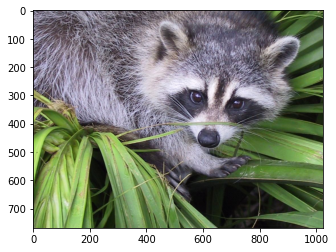

```python
from scipy import misc
import matplotlib.pyplot as plt
import numpy as np
import copy
# assign the matrix of numbers that represent the image to a variable.
f = misc.face()
# The following line shows the image in the notebook.
plt.imshow(f)
f_shape = np.shape(f)
#The following line shows the matrix of numbers that represents the picture.
#Note the numbers are between 0 and 255. These represent different colors
print(f[0])
```

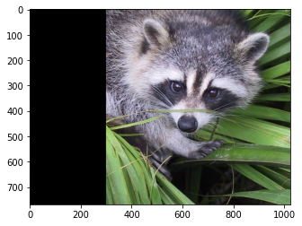

```python
# creating a copy of the variable, so we can play with it
f1 = copy.deepcopy(f)
# make a bunch of entries in the matrix zero.
f1[:,1:300,:]=np.zeros([f_shape[0],299,f_shape[2]])
plt.imshow(f1)
```

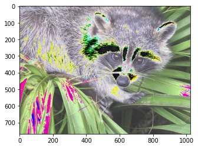

```python
# As we discussed above, the numbers represent the colors of pixels. So, let's just play
# with these numbers and add 50 to each number in the matrix
x_filter = 50*np.ones(np.shape(f),dtype='uint8')
# type(x_filter)
f1 = f+x_filter
#plt.show()
plt.imshow(f1)
```

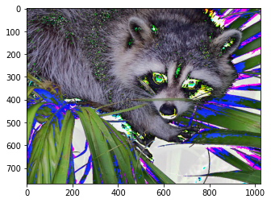

```python
# Now we subtract 50 from each number in the matrix and see what happens.
f2 = f-x_filter
plt.show()
plt.imshow(f2)
```

# Logic Gates

- **Logic gates** transform an input string of bits into an output string of bits. - They are the building blocks of any computation: they can be combined with other logic gates to create large circuits that implement complex algorithms.

[figure not shown]

## Single bit logic gates

- **Single bit** logic gates take a single bit as input. - They output a single bit. - Example: NOT-gate, which flips the value of the input bit.

[figure not shown]

- Are there other single bit logic gates other than the NOT gate? Not many.
- Four distinct possible ways to map the set $\{0,1\}$ to $\{0,1\}$. Other than the mapping $0 \rightarrow 1$, $1 \rightarrow 0$, which corresponds to the **NOT** gate, there are three others:
1. The mapping $0 \rightarrow 0$, $1 \rightarrow 1$ corresponds to the **identity** gate (i.e. the gate that outputs the input without changes).
2. And the mappings $0 \rightarrow 0$, $1 \rightarrow 0$, and $0 \rightarrow 1$, $1 \rightarrow 1$. These map the input to a constant output.

## Two bit logic gates

[figure not shown]

## Larger Circuits

[figure not shown]

## A Universal Set of Gates

- A very small set of logic gates suffices to implement *any* function from $n$ bits to $1$, just $\{\text{AND}, \text{NOT}\}$
- This set of logic gates $\{\text{AND}, \text{NOT}\}$ is referred to as a *universal set of gates*.

The fact that such small universal sets of gates exist greatly simplifies the process of developing circuits, as a manufacturer can focus on just a few types of logic gates.